# 326.212 Final Project: Part 3

## 2013-11086 김찬규

```r
library(RSQLite)
library(DBI)
library(tidyverse)
library(lubridate)
library(zoo)
library(modelr)
library(stringr)
con <- dbConnect(SQLite(), "project.sqlite")
```

## Part 3. Advanced Questions (100 pts)

### Q1. When is the best time of day/day of week/time of year to fly to minimise delays? (50 pts)

Let’s assume that we care about arrival delays other than departure delays.

```r
# Sampling from original data
flights <- dbGetQuery(
    con, "SELECT * FROM flights ORDER BY RANDOM() LIMIT 100000;"
  ) %>%
  filter(
    Arr_Delay >= 0
  )
```

```r
# We can use this code instead for population data
flights <- tbl(con, "flights")
```

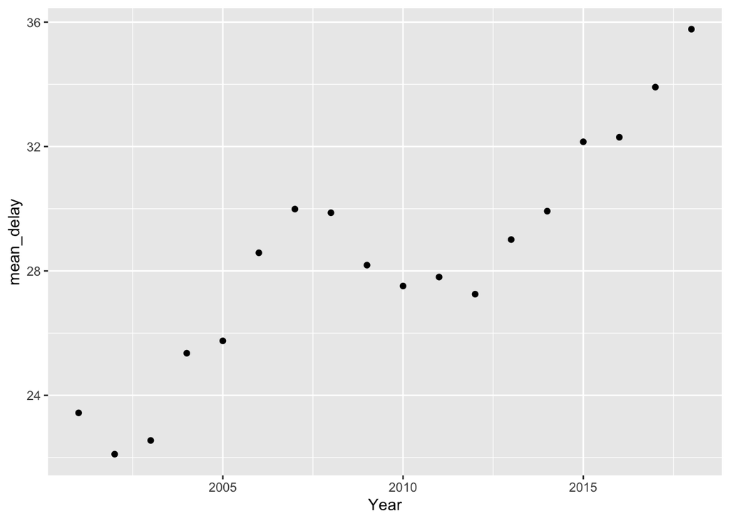

```r
# Mean delays for each year
flights %>%
  group_by(Year) %>%
  summarize(mean_delay = mean(Arr_Delay)) %>%
  ggplot(aes(Year, mean_delay)) +
  geom_point()
```

There is a strong tendency that arrival delay times increase year by year. So First we get rid of the yearly effect on delay to get results which is independent from yearly effect.

```r
# Linear model for yearly effect
mod1 <- lm(Arr_Delay ~ Year + I(Year**2) + I(Year**3), flights)
summary(mod1)
```

```
##
## Call:
## lm(formula = Arr_Delay ~ Year + I(Year^2) + I(Year^3), data = flights)
##
## Residuals:
##     Min      1Q  Median      3Q     Max
##  -35.89  -23.35  -15.27    4.12 1339.07
##
## Coefficients:
##               Estimate Std. Error t value Pr(>|t|)
## (Intercept) -8.132e+07  1.676e+07  -4.853 1.22e-06 ***
## Year         1.214e+05  2.502e+04   4.853 1.22e-06 ***
## I(Year^2)   -6.042e+01  1.245e+01  -4.853 1.22e-06 ***
## I(Year^3)    1.002e-02  2.065e-03   4.853 1.22e-06 ***
## ---
## Signif. codes:  0 '***' 0.001 '**' 0.01 '*' 0.05 '.' 0.1 ' ' 1
##
## Residual standard error: 46.35 on 42067 degrees of freedom
## Multiple R-squared:  0.004973,   Adjusted R-squared:  0.004902
## F-statistic: 70.08 on 3 and 42067 DF,  p-value: < 2.2e-16
```

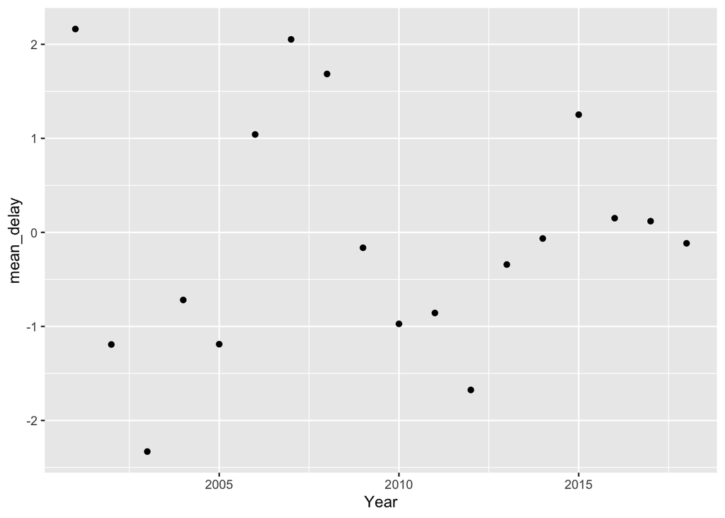

```r
# Get rid of yearly effect
delays <- flights %>%
  add_residuals(mod1, var = "arr_delay")

delays %>%
  group_by(Year) %>%
  summarize(mean_delay = mean(arr_delay, na.rm = TRUE)) %>%
  ggplot(aes(Year, mean_delay)) +
  geom_point()
```

I also doubt that daily/monthly number of flights affect delay times. This could lead to misleading results if not considered.

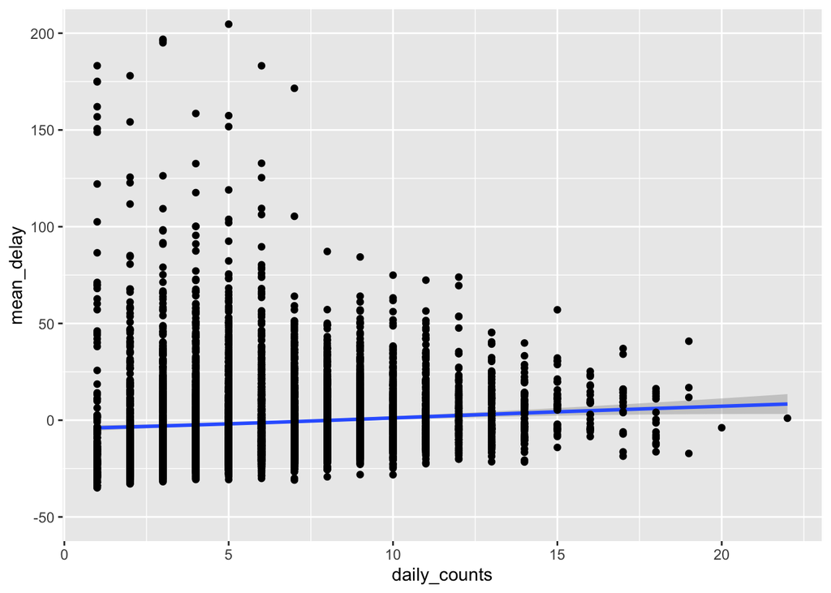

```r
# Daily mean delays
daily_delays <- delays %>%
  group_by(Year, Month, Day_of_Month) %>%
  summarize(
    daily_counts = n(),
    mean_delay = mean(arr_delay, na.rm = TRUE)
  )

daily_delays %>%
  ggplot(aes(daily_counts, mean_delay)) +
  geom_smooth(na.rm = TRUE) +
  geom_point(na.rm = TRUE) +
  coord_cartesian(ylim = c(-50, 200))
```

```r
mod2 <- lm(mean_delay ~ daily_counts, daily_delays)
summary(mod2)
```

```
##
## Call:
## lm(formula = mean_delay ~ daily_counts, data = daily_delays)
##
## Residuals:
##    Min     1Q Median     3Q    Max
## -30.53 -13.84  -5.53   7.07 503.33
##
## Coefficients:
##              Estimate Std. Error t value Pr(>|t|)
## (Intercept)  -4.97615    0.66362  -7.499 7.31e-14 ***
## daily_counts  0.62121    0.09234   6.727 1.87e-11 ***
## ---
## Signif. codes:  0 '***' 0.001 '**' 0.01 '*' 0.05 '.' 0.1 ' ' 1
##
## Residual standard error: 23.68 on 6523 degrees of freedom
## Multiple R-squared:  0.00689,    Adjusted R-squared:  0.006738
## F-statistic: 45.26 on 1 and 6523 DF,  p-value: 1.874e-11
```

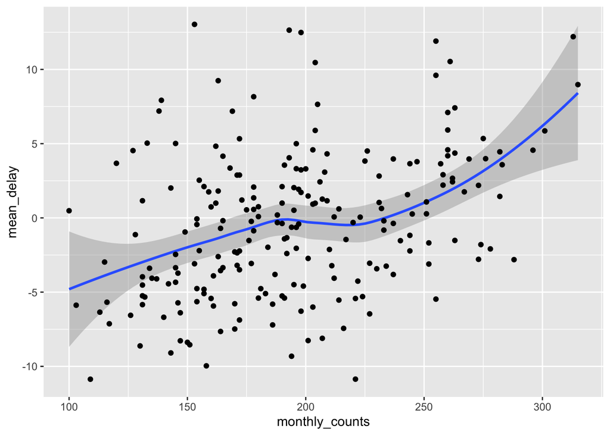

```r
# Monthly mean delays
monthly_delays <- delays %>%
  group_by(Year, Month) %>%
  summarize(
    monthly_counts = n(),
    mean_delay = mean(arr_delay, na.rm = TRUE)
  )

monthly_delays %>%
  ggplot(aes(monthly_counts, mean_delay)) +
  geom_smooth(na.rm = TRUE) +
  geom_point(na.rm = TRUE)
```

```r
mod3 <- lm(mean_delay ~ monthly_counts, monthly_delays)
summary(mod3)
```

```
##
## Call:
## lm(formula = mean_delay ~ monthly_counts, data = monthly_delays)
##
## Residuals:
##      Min       1Q   Median       3Q      Max
## -11.4632  -3.3865  -0.3051   2.4667  15.1075
##
## Coefficients:
##                 Estimate Std. Error t value Pr(>|t|)
## (Intercept)    -8.093580   1.341165  -6.035 6.93e-09 ***
## monthly_counts  0.039351   0.006701   5.873 1.62e-08 ***
## ---
## Signif. codes:  0 '***' 0.001 '**' 0.01 '*' 0.05 '.' 0.1 ' ' 1
##
## Residual standard error: 4.539 on 214 degrees of freedom
## Multiple R-squared:  0.1388, Adjusted R-squared:  0.1348
## F-statistic: 34.49 on 1 and 214 DF,  p-value: 1.622e-08
```

So in order to inspect the affect of `time of day` holding the number of daily/monthly flights constant, it is reasonable to get rid of the affect of the nubmer of flights.

```r
# Get rid of number of flights effect
delays_with_counts <- delays %>%
  group_by(Year, Month, Day_of_Month) %>%
  mutate(
    daily_count = n()
  ) %>%
  ungroup() %>%
  group_by(Year, Month) %>%
  mutate(
    monthly_count = n()
  ) %>%
  ungroup() %>%
  mutate(
    dep_hour = substring(Dep_Time, 1, 2) %>% parse_integer(),
    dep_ten_minute = substring(Dep_Time, 3, 3) %>% parse_integer()
  )

mod4 <- lm(arr_delay ~ daily_count + monthly_count, delays_with_counts)
summary(mod4)
```

```
##
## Call:
## lm(formula = arr_delay ~ daily_count + monthly_count, data = delays_with_counts)
##
## Residuals:
##     Min      1Q  Median      3Q     Max
##  -44.44  -23.39  -15.02    4.29 1342.26
##
## Coefficients:
##                Estimate Std. Error t value Pr(>|t|)
## (Intercept)   -9.102264   1.025141  -8.879  < 2e-16 ***
## daily_count    0.527615   0.076414   6.905 5.10e-12 ***
## monthly_count  0.023706   0.005446   4.353 1.35e-05 ***
## ---
## Signif. codes:  0 '***' 0.001 '**' 0.01 '*' 0.05 '.' 0.1 ' ' 1
##
## Residual standard error: 46.28 on 42068 degrees of freedom
## Multiple R-squared:  0.002829,   Adjusted R-squared:  0.002781
## F-statistic: 59.67 on 2 and 42068 DF,  p-value: < 2.2e-16
```

```r
delays_timod <- delays_with_counts %>%
  add_residuals(mod4)
```

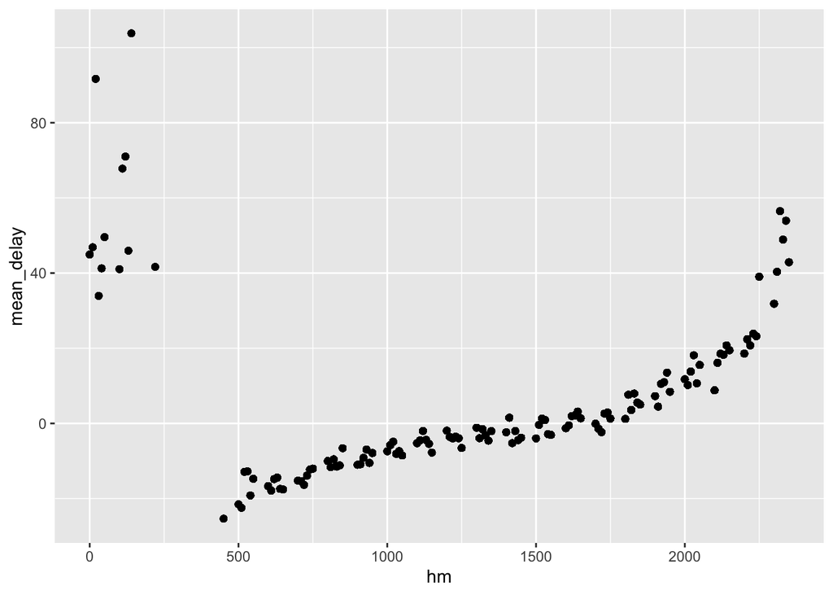

```r
# Plot for delay on time
delays_timod %>%
  group_by(dep_hour, dep_ten_minute) %>%
  filter(n() > 5) %>%
  mutate(
    mean_delay = mean(resid, na.rm = TRUE),
    hm = dep_hour*100 + dep_ten_minute*10
  ) %>%
  ggplot(aes(hm, mean_delay)) +
  geom_point()
```

Average delays for flights are smallest at 05:00, which is the very start of a day. Then mean delay monotonously increases with the time of the day. So you would better take a flight which departs as early as possible if you care about the arrival delay time.

In order to inspect the affect of `day of week` to arrival delay, it is reasonable to remove the affect of monthly flights.

```r
# Get rid of monthly count effect only
mod5 <- lm(arr_delay ~ monthly_count, delays_with_counts)
summary(mod5)
```

```
##
## Call:
## lm(formula = arr_delay ~ monthly_count, data = delays_with_counts)
##
## Residuals:
##     Min      1Q  Median      3Q     Max
##  -38.16  -23.52  -15.22    4.23 1341.84
##
## Coefficients:
##                Estimate Std. Error t value Pr(>|t|)
## (Intercept)   -8.424795   1.021001  -8.252   <2e-16 ***
## monthly_count  0.040961   0.004841   8.461   <2e-16 ***
## ---
## Signif. codes:  0 '***' 0.001 '**' 0.01 '*' 0.05 '.' 0.1 ' ' 1
##
## Residual standard error: 46.31 on 42069 degrees of freedom
## Multiple R-squared:  0.001699,   Adjusted R-squared:  0.001675
## F-statistic: 71.59 on 1 and 42069 DF,  p-value: < 2.2e-16
```

```r
delays_daow <- delays_with_counts %>%
  add_residuals(mod5)
```

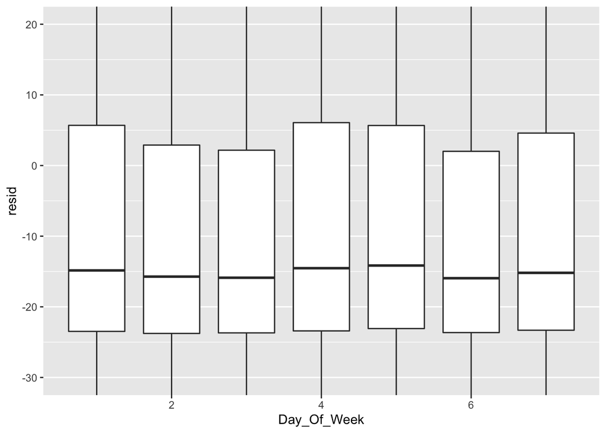

```r
# Plot for delay on weekday
delays_daow %>%
  ggplot(aes(Day_Of_Week, resid)) +
  geom_boxplot(aes(group = Day_Of_Week, middle = mean(resid))) +
  coord_cartesian(ylim = c(-30, 20))
```

```r
# Summary table for delay on weekday
delays_daow %>%
  group_by(Day_Of_Week) %>%
  summarize(
    mean_delay = mean(resid, na.rm = TRUE),
    sd_mean_delay = sd(resid, na.rm = TRUE)/sqrt(n()),
    CI_inf = mean_delay - 1.96*sd_mean_delay,
    CI_sup = mean_delay + 1.96*sd_mean_delay
  ) %>%
  arrange(mean_delay)
```

```
## # A tibble: 7 x 5
##   Day_Of_Week mean_delay sd_mean_delay CI_inf CI_sup
##         <dbl>      <dbl>         <dbl>  <dbl>  <dbl>
## 1           3     -1.72          0.552 -2.80  -0.638
## 2           6     -1.61          0.667 -2.92  -0.306
## 3           2     -1.55          0.581 -2.69  -0.413
## 4           5      0.563         0.533 -0.481  1.61
## 5           7      0.893         0.652 -0.385  2.17
## 6           4      1.31          0.560  0.213  2.41
## 7           1      1.48          0.646  0.218  2.75
```

Now let’s inspect the affect of month to delays.

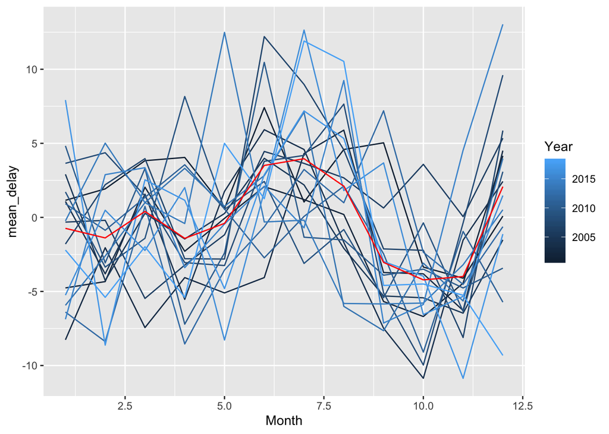

```r
# Plot for delay on month
delays %>%
  group_by(Year, Month) %>%
  summarize(
    mean_delay = mean(arr_delay, na.rm = TRUE)
  ) %>%
  ggplot(aes(Month, mean_delay)) +
  geom_line(aes(group = Year, color = Year)) +
  geom_line(
    data = delays %>%
      group_by(Month) %>%
      summarize(mean_delay = mean(arr_delay)),
    color = "red"
  )
```

It is obvious that there is a pattern in which delay times are quite big during summertime, while delay times are quite small during spring or fall. Looking at the red line, delay for October is expected to be smallest among months.

```r
# Summary table for delay on month
delays %>%
  group_by(Month) %>%
  summarize(
    mean_delay = mean(arr_delay),
    sd_mean_delay = sd(arr_delay)/sqrt(n()),
    CI_inf = mean_delay - 1.96*sd_mean_delay,
    CI_inf = mean_delay + 1.96*sd_mean_delay
  ) %>%
  arrange(mean_delay)
```

```
## # A tibble: 12 x 4
##    Month mean_delay sd_mean_delay  CI_inf
##    <dbl>      <dbl>         <dbl>   <dbl>
##  1    10     -4.22          0.679 -2.89
##  2    11     -3.99          0.703 -2.61
##  3     9     -3.04          0.932 -1.21
##  4     4     -1.42          0.777  0.107
##  5     2     -1.39          0.685 -0.0440
##  6     1     -0.740         0.691  0.615
##  7     5     -0.403         0.790  1.14
##  8     3      0.404         0.757  1.89
##  9    12      2.08          0.828  3.70
## 10     8      2.11          0.836  3.75
## 11     6      3.51          0.785  5.05
## 12     7      3.96          0.806  5.54
```

Specifically, you are expected to save about 4.3 minutes on average by taking a flight on Octover.

### Q2. Do older planes suffer more delays? (50 pts)

```r
# Calculate airplane age
flights_age <- tbl(con, "flights") %>%
  inner_join(
    tbl(con, "airplanes") %>% filter(!is.na(Year), Year > 0),
    by = c("Tail_Num" = "TailNum"),
    suffix = c("", ".airplanes")
  ) %>%
  mutate(
    Age = Year - Year.airplanes
  ) %>%
  select(
    Year,
    Month,
    Day_of_Month,
    Age,
    Dep_Delay,
    Origin,
    Dest,
    Op_Unique_Carrier,
    Cancelled,
    Tail_Num
  )

delays_age <- flights_age %>%
  group_by(Age) %>%
  summarize(
    mean_delay = mean(Dep_Delay, na.rm = TRUE),
    counts = n()
  ) %>%
  filter(
    counts > 5,
    Age >= 0
  ) %>%
  collect()

delays_age
```

```
## # A tibble: 62 x 3
##      Age mean_delay  counts
##    <dbl>      <dbl>   <int>
##  1     0       8.48  590203
##  2     1       8.10 1693180
##  3     2       7.94 2202601
##  4     3       8.10 2619650
##  5     4       8.50 2866194
##  6     5       8.61 2979660
##  7     6       8.89 3051755
##  8     7       9.17 3246217
##  9     8       9.26 3290654
## 10     9       9.24 3405741
## # … with 52 more rows
```

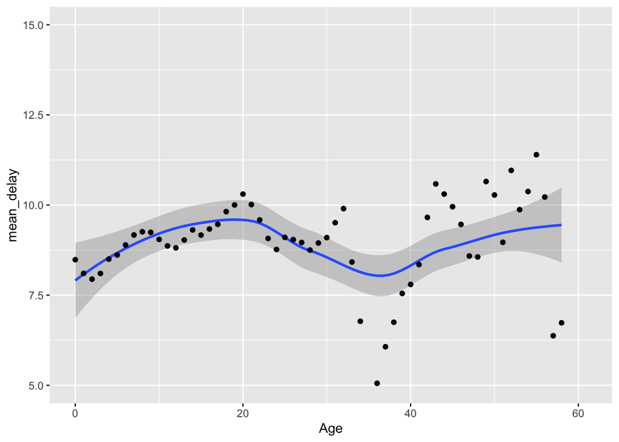

```r
# Plot for delay on age
delays_age %>%
  ggplot(aes(Age, mean_delay)) +
  geom_smooth(na.rm = TRUE) +
  geom_point(na.rm = TRUE) +
  ggplot2::ylim(5, 15)
```

It seems that older planes suffer more delays given the age of planes between 0 and 20. But we can pose two questions: 1) what if the relationship is affected by other variables, such as airport and airlines? 2) why the mean delay drops after age 20?

To deal with the first question, we can inspect the effect of a doubtful variable. Let’s fit a model by regressing delays on origin airports and airlines. Here I fit a model with a sample with size 100,000 because of memory problem.

```r
# Data preprocessing for model fitting
flights_age_sample <- dbGetQuery(
    con,
    "SELECT * FROM flights ORDER BY RANDOM() LIMIT 100000;"
  ) %>%
  inner_join(
    tbl(con, "airplanes") %>% filter(!is.na(Year), Year > 0) %>% collect(),
    by = c("Tail_Num" = "TailNum"),
    suffix = c("", ".airplanes")
  ) %>%
  mutate(
    Age = Year - Year.airplanes,
    Origin = factor(Origin),
    Op_Unique_Carrier = factor(Op_Unique_Carrier)
  ) %>%
  filter(!is.na(Op_Unique_Carrier)) %>%
  select(
    Year,
    Month,
    Day_of_Month,
    Age,
    Dep_Delay,
    Origin,
    Dest,
    Op_Unique_Carrier,
    Cancelled,
    Tail_Num
  ) %>%
  group_by(Origin) %>%
  filter(n() > 1) %>%
  ungroup() %>%
  group_by(Op_Unique_Carrier) %>%
  filter(n() > 1) %>%
  ungroup()

# Model for delay on airports/airlines
mod6 <- lm(
  Dep_Delay ~ Origin + Op_Unique_Carrier,
  flights_age_sample
)
summary(mod6)
```

```
##
## Call:
## lm(formula = Dep_Delay ~ Origin + Op_Unique_Carrier, data = flights_age_sample)
##
## Residuals:
##     Min      1Q  Median      3Q     Max
##  -99.00  -13.57   -9.41   -0.99 1086.29
##
## Coefficients:
##                        Estimate Std. Error t value Pr(>|t|)
## (Intercept)            2.232315   7.224186   0.309 0.757318
## OriginABI              0.085934  13.593968   0.006 0.994956
## OriginABQ             -1.356034   6.354244  -0.213 0.831011
## OriginABR            -11.663176  25.139058  -0.464 0.642688
## OriginABY             72.410892  11.272678   6.424 1.34e-10 ***
## OriginACK             31.892024  25.138479   1.269 0.204570
## OriginACT             -8.440962  16.549744  -0.510 0.610028
## OriginACV              2.229681   8.836855   0.252 0.800798
## OriginACY            -17.158987  18.262652  -0.940 0.347444
## OriginADQ             -5.780478  20.838907  -0.277 0.781483
## OriginAEX             -8.069424   8.738737  -0.923 0.355798
## OriginAGS             12.361701   9.106768   1.357 0.174654
## OriginALB              4.598978   6.910132   0.666 0.505707
## OriginAMA             -5.276658   7.423809  -0.711 0.477227
## OriginANC             -3.329883   6.484502  -0.514 0.607594
## OriginAPF             -9.249602  25.136257  -0.368 0.712891
## OriginASE              0.938278   8.280297   0.113 0.909782
## OriginATL              4.132235   5.960513   0.693 0.488144
## OriginATW            -10.567431   8.510047  -1.242 0.214331
## OriginAUS              0.855899   6.197039   0.138 0.890151
## OriginAVL             -5.584566   8.159481  -0.684 0.493709
## OriginAVP             -6.289682  11.984009  -0.525 0.599697
## OriginAZO             -4.343578   9.592172  -0.453 0.650676
## OriginBDL              1.266657   6.418004   0.197 0.843547
## OriginBET             -7.669367  13.005922  -0.590 0.555406
## OriginBFL             -2.631792   7.663727  -0.343 0.731292
## OriginBGM             -2.747312  20.811140  -0.132 0.894976
## OriginBGR             -5.243817  11.603048  -0.452 0.651318
## OriginBHM             -4.515546   6.469548  -0.698 0.485199
## OriginBIL              1.475355   7.860358   0.188 0.851116
```

[output cut: 301 more lines]

```
## Op_Unique_CarrierNW    1.382495   4.202333   0.329 0.742170
## Op_Unique_CarrierOH    7.557065   4.269859   1.770 0.076755 .
## Op_Unique_CarrierOO    4.430861   4.160047   1.065 0.286836
## Op_Unique_CarrierUA    5.423903   4.150988   1.307 0.191336
## Op_Unique_CarrierUS    1.194084   4.175564   0.286 0.774903
## Op_Unique_CarrierWN    6.394644   4.139373   1.545 0.122392
## Op_Unique_CarrierXE    4.178637   4.190387   0.997 0.318674
## Op_Unique_CarrierYV    3.213411   4.266410   0.753 0.451340
## ---
## Signif. codes:  0 '***' 0.001 '**' 0.01 '*' 0.05 '.' 0.1 ' ' 1
##
## Residual standard error: 34.54 on 55461 degrees of freedom
##   (519 observations deleted due to missingness)
## Multiple R-squared:  0.0159, Adjusted R-squared:  0.0099
## F-statistic: 2.651 on 338 and 55461 DF,  p-value: < 2.2e-16
```

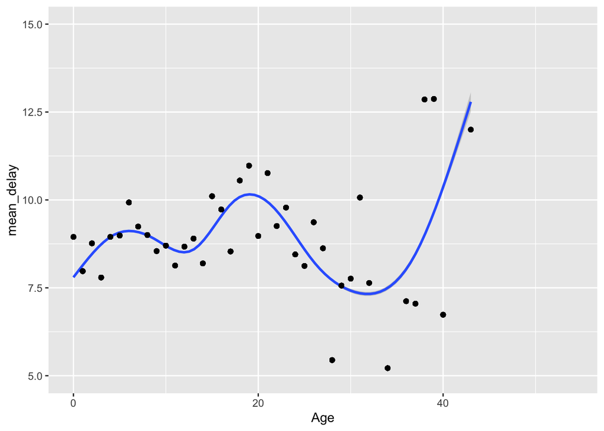

```r
# Plot for delay on age - airports/airlines effects removed
flights_age_sample %>%
  add_residuals(mod6) %>%
  group_by(Age) %>%
  mutate(
    mean_delay = mean(Dep_Delay, na.rm = TRUE),
    counts = n()
  ) %>%
  filter(counts > 5) %>%
  ggplot(aes(Age, mean_delay)) +
  geom_smooth(na.rm = TRUE) +
  geom_point(na.rm = TRUE) +
  ggplot2::ylim(5, 15)
```

It seems that the trend of graph is almost the same. Actually, the model does not explain the data well. We can conclude that older airplanes tend to suffer more delays given that the ages under about 20 years. The difference is at most about 3 minutes in average (between newborn airplanes and 20 year old airplanes).

```r
delays_age %>%
  filter(Age > 20)
```

```
## # A tibble: 41 x 3
##      Age mean_delay  counts
##    <dbl>      <dbl>   <int>
##  1    21      10.0  1322418
##  2    22       9.59 1155038
##  3    23       9.07 1000100
##  4    24       8.77  800685
##  5    25       9.10  643198
##  6    26       9.04  545818
##  7    27       8.96  419954
##  8    28       8.75  306796
##  9    29       8.95  206523
## 10    30       9.10  135923
## # … with 31 more rows
```

```r
# Standard deviation of delay for older airplanes
delays_age %>%
  filter(Age > 20) %>%
  summarize(
    sd = sd(mean_delay, na.rm = TRUE),
    counts = sum(counts)
  )
```

```
## # A tibble: 1 x 2
##      sd  counts
##   <dbl>   <int>
## 1  4.49 7572989
```

```r
# Standard deviation of delay for younger airplanes
delays_age %>%
  filter(Age <= 20) %>%
  summarize(
    sd = sd(mean_delay, na.rm = TRUE),
    counts = sum(counts)
  )
```

```
## # A tibble: 1 x 2
##      sd   counts
##   <dbl>    <int>
## 1 0.609 58439365
```

Moreover, because the number of old flights is quite small, it can be said that the older airplanes suffer more delay on average in a range that most of the data reside in.

```r
dbDisconnect(con)
```